# pca

Roman Olenev

2023-10-25

```r
dataset <- read.csv("IFDGIPLI.DAT", sep="")
head(dataset)
```

```
##   NUM IDGI FDGI IPLI FPLI
## 1   1 1.15 1.15 1.08 1.08
## 2   4 1.29 1.30 1.34 1.13
## 3   6 1.28 1.14 1.78 1.35
## 4   7 0.85 1.02 1.18 0.92
## 5   8 1.10 1.03 1.25 1.08
## 6  10 0.81 1.07 1.32 1.22
```

```r
data <- dataset[,-1]
head(data)
```

```
##   IDGI FDGI IPLI FPLI
## 1 1.15 1.15 1.08 1.08
## 2 1.29 1.30 1.34 1.13
## 3 1.28 1.14 1.78 1.35
## 4 0.85 1.02 1.18 0.92
## 5 1.10 1.03 1.25 1.08
## 6 0.81 1.07 1.32 1.22
```

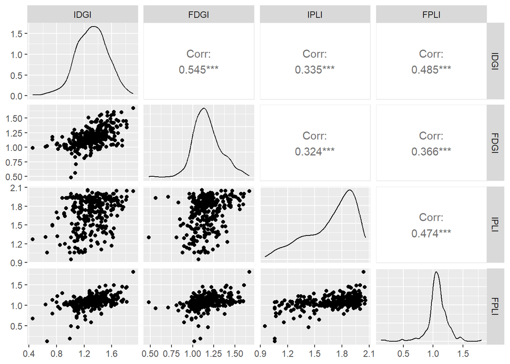

```r
ggpairs(data)
```

```r
res.pca <- PCA(data, ncp=4)
```

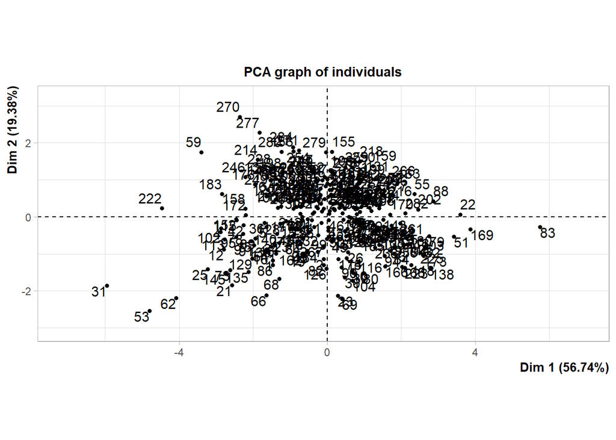

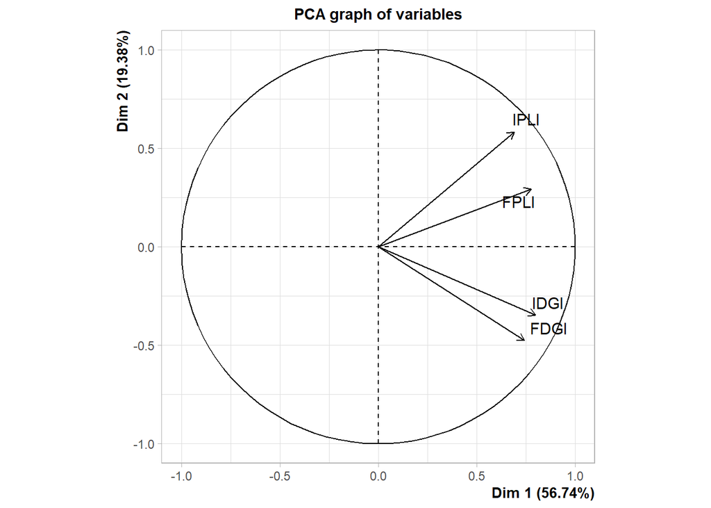

Первый график - проекции индивидов на пространство из первых 2 главных компонент ($z_{i1},z_{i2}$)

Второй график - исходные признаки с координатами ($f_{i1},f_{i2}$) равными корреляции между ними и главными компонентами

Векторы U

Интерпретируем новые признаки на основе формулы $Z_i=XU_i$ (линейная комбинация исходных признаков)

Первая главная компонента - общий уровень (чем больше значение, тем менее здоровый человек)

Вторая главная компонента - разнца между индексами

Третья главная комопнента - разница между FDGI+IPLI и IDGI+FPLI

Четвертая главная компонента - разница по времени (F - I)

```r
res.pca$svd$V
```

```
##           [,1]       [,2]       [,3]       [,4]
## [1,] 0.5297367 -0.3948382 -0.2892770 -0.6926765
## [2,] 0.4932108 -0.5410033  0.4769561  0.4863861
## [3,] 0.4581916  0.6635975  0.5352594 -0.2513885
## [4,] 0.5159289  0.3332516 -0.6342942  0.4695015
```

Собственные числа и вклад в общую дисперсию

```r
res.pca$eig
```

```
##        eigenvalue percentage of variance cumulative percentage of variance
## comp 1  2.2694964               56.73741                          56.73741
## comp 2  0.7751690               19.37922                          76.11663
## comp 3  0.5455048               13.63762                          89.75425
## comp 4  0.4098299               10.24575                         100.00000
```

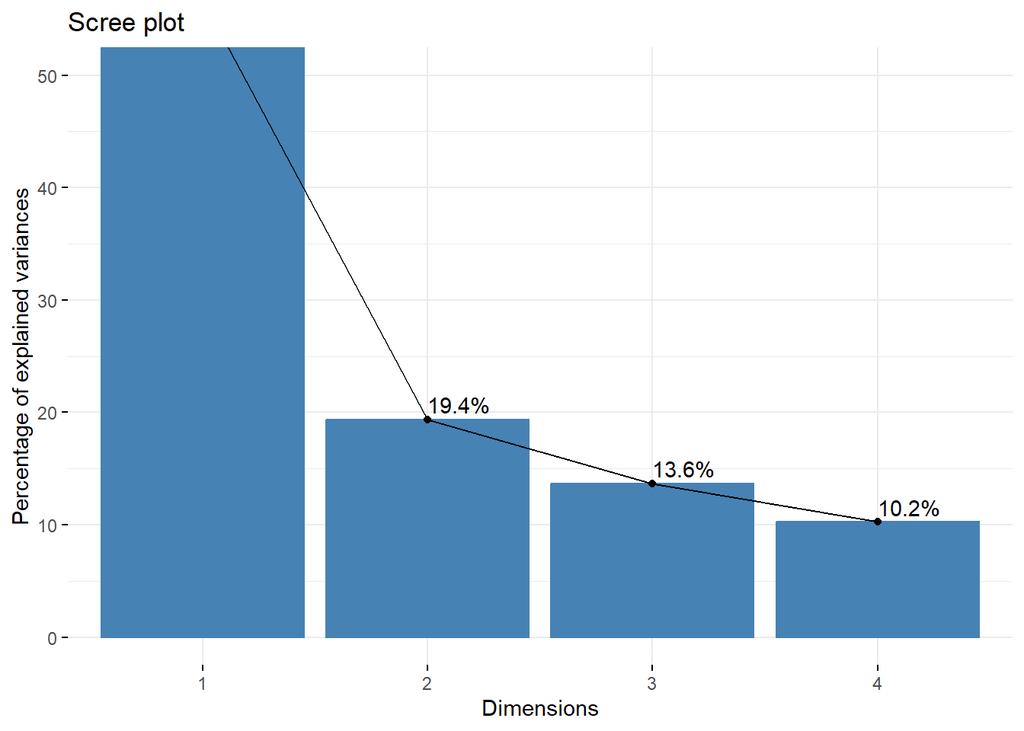

```r
fviz_eig(res.pca, addlabels = TRUE, ylim = c(0, 50))
```

Координаты признаков (матрица F)

```r
res.pca$var$coord
```

```
##          Dim.1      Dim.2      Dim.3      Dim.4
## IDGI 0.7980402 -0.3476301 -0.2136550 -0.4434373
## FDGI 0.7430146 -0.4763192  0.3522716  0.3113744
## IPLI 0.6902587  0.5842556  0.3953335 -0.1609338
## FPLI 0.7772390  0.2934070 -0.4684788  0.3005653
```

$f_{ij}^2$

```r
res.pca$var$cos2
```

```
##          Dim.1      Dim.2      Dim.3      Dim.4
## IDGI 0.6368682 0.12084666 0.04564847 0.19663666
## FDGI 0.5520707 0.22688001 0.12409529 0.09695403
## IPLI 0.4764571 0.34135463 0.15628856 0.02589969
## FPLI 0.6041004 0.08608767 0.21947243 0.09033948
```

$\frac{f_{ij}^2}{\lambda_j}\cdot{100}$, фактически векторы U с элементами, возведенными в квадрат и умноженными на 100

```r
res.pca$var$contrib
```

```
##         Dim.1    Dim.2     Dim.3     Dim.4
## IDGI 28.06209 15.58972  8.368117 47.980072
## FDGI 24.32569 29.26846 22.748709 23.657142
## IPLI 20.99396 44.03616 28.650265  6.319619
## FPLI 26.61826 11.10567 40.232909 22.043168
```

Координаты индивидов в новых признаках (матрица Z)

```r
res.pca$ind$coord[1:6,]
```

```
##         Dim.1      Dim.2      Dim.3     Dim.4
## 1 -1.47183235 -1.1811279 -1.1362682 1.0308856
## 2 -0.09919211 -1.1462186 -0.5482606 0.9284618
## 3  0.85786484  0.9367315 -0.9224281 0.6926659
## 4 -2.86726663 -0.3100157 -0.3121636 1.0230834
## 5 -1.64134323 -0.2791905 -1.0645476 0.6738589
## 6 -1.64439140  0.5510464 -0.9710337 1.9959826
```

$\frac{z_{ij}^2}{||x_i||^2}$, $x_i$ - индивид

```r
res.pca$ind$cos2[1:6,]
```

```
##         Dim.1      Dim.2      Dim.3     Dim.4
## 1 0.366225375 0.23584440 0.21826969 0.1796605
## 2 0.003957337 0.52842530 0.12089901 0.3467183
## 3 0.249972043 0.29804642 0.28901390 0.1629676
## 4 0.868915190 0.01015801 0.01029926 0.1106275
## 5 0.617990555 0.01788069 0.25996398 0.1041648
## 6 0.340791907 0.03826971 0.11883586 0.5021025
```

Индивиды и проекции ортов ($\tilde{z}_{ij}=\langle e_i,U_j \rangle,\ i=\overline{1,4},\ j=\overline{1,2}$) в плоскости первых 2 главных компонент

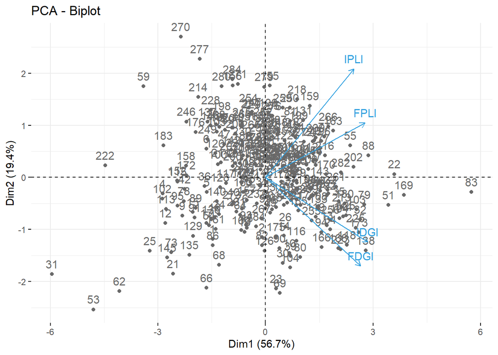

```r
fviz_pca_biplot(res.pca, repel = FALSE,
                col.var = "#2E9FDF",
                col.ind = "#696969"
                )
```

Выброс, индивид 31: Общий уровень существенно ниже среднего (т.к. минимальное значение по первой главной компоненте), то есть индивид более здоров, чем группа в среднем. Разность между PLI и DGI ниже среднего. (У индивида самые здоровые в целом зубы, по индексам ситуация с DGI хуже, чем с PLI)

```r
data[31,]
```

```
##    IDGI FDGI IPLI FPLI
## 31 0.66 1.02 1.06 0.13
```

Выброс, индивид 83: У индивида самые больные в целом зубы, ситуация плохая по обоим индексам, так как вторая главная компонента близка к 0

```r
data[83,]
```

```
##    IDGI FDGI IPLI FPLI
## 83 1.91 1.67 2.04 1.81
```

Удалим выбросы

```r
res.pca2 <- PCA(data[-c(31,83),], ncp=4)
```

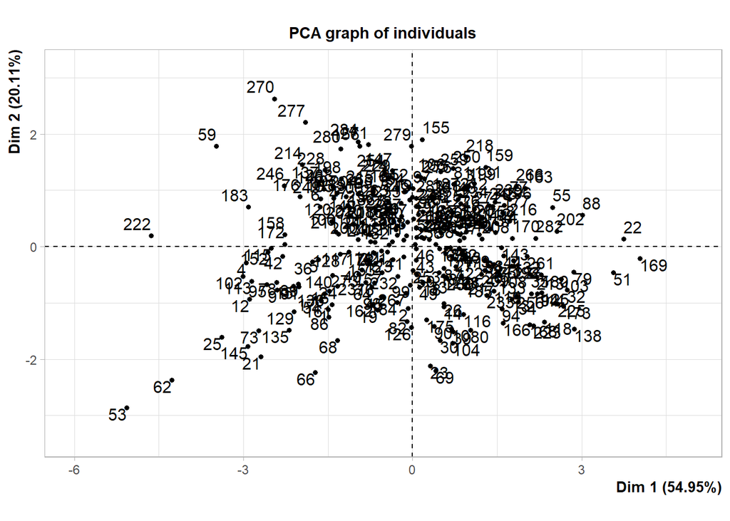

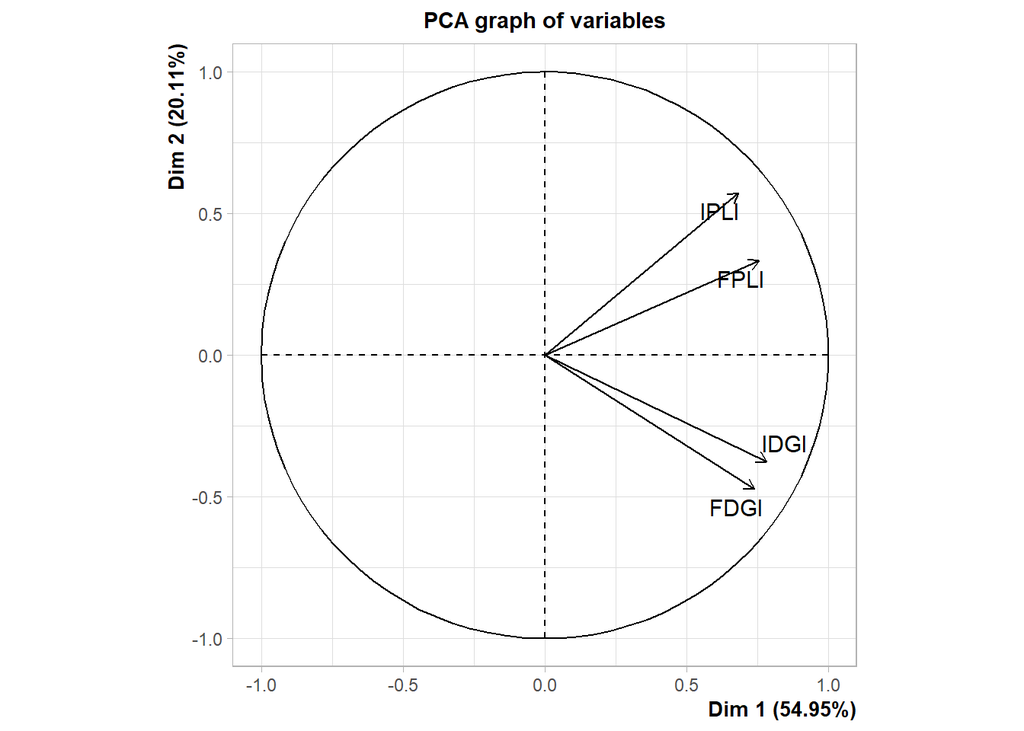

Biplot без выбросов

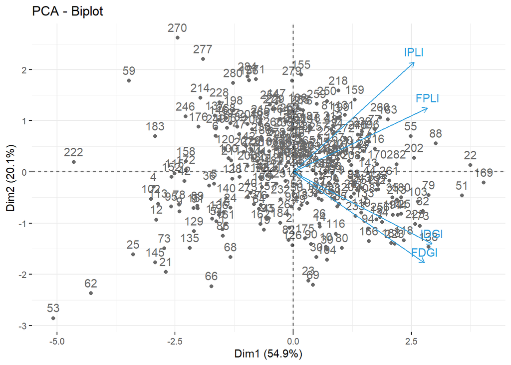

```r
fviz_pca_biplot(res.pca2, repel = FALSE,
                col.var = "#2E9FDF",
                col.ind = "#696969"
                )
```